# Confusion Metrics

Glenn Slade

02/12/2022

## Background

This script explores in more detail the accuracy asessment results derived from the random forest classification carried out with the SKlearn machine learning package in Python. This script uses the diffeR package in R and explores the alternatives to using kappa for confusion matrix accuracy assessment and calculates confusion matrix metrics as per Pontius Jr., R.G., Millones, M. 2011. Death to Kappa: birth of quantity disagreement and allocation disagreement for accuracy assessment. International Journal of Remote Sensing 32 (15), 4407-4429.

```r
Confusion1 <- read.csv("E:/Glenn/Botswana/RF/Python/Bokspits_1/Bokspits_1_RF_conf_matrix.csv")
Base_results <- read.csv("E:/Glenn/Botswana/RF/Python/Bokspits_1/Bokspits_1_RF_CHM_Summary.txt", header = FALSE)
Importance <- read.csv("E:/Glenn/Botswana/RF/Python/Bokspits_1/Bokspits_1_RF_CHM_Importance.txt")

# Prepare data table for diffeR package

Confusion4 <- subset(Confusion1, select = -c(row_0,All) )#removes unwanted columns from original Python output
Confusion3 <- Confusion4[-c(7),]#removes the last totals row
Confusion2 <- as.matrix(Confusion3) #converts table into matrix
```

Basic accuracy assesment produced by Sklearn python machine learning package is given below.  
Information about precision, recall, f1_score calculations can be found at http://scikit-learn.org/stable/modules/generated/sklearn.metrics.precision_recall_fscore_support.html We can now calculate quantity, exchange and shift components of difference, as well as the overall difference, at the category level from a contingency table derived from the crosstabulation between a comparison variables and a reference variable.

```r
print (Base_results)
```

```
##                                                       V1
## 1                precision    recall  f1-score   support
## 2             1       0.82      0.84      0.83       972
## 3             2       1.00      0.90      0.95       757
## 4             3       0.83      0.82      0.83       656
## 5             4       1.00      0.91      0.95       662
## 6             5       0.83      0.75      0.79       664
## 7             6       0.80      0.99      0.89       777
## 8      accuracy                           0.87      4488
## 9     macro avg       0.88      0.87      0.87      4488
## 10 weighted avg       0.88      0.87      0.87      4488
```

The Band Selection Importance Scores are

```r
print (Importance)
```

```
##   Band.1.importance..0.13896318638558747
## 1 Band 2 importance: 0.11362769337773432
## 2  Band 3 importance: 0.2511907393409517
## 3  Band 4 importance: 0.1135281709121766
## 4 Band 5 importance: 0.15479913834678272
## 5 Band 6 importance: 0.22789107163676722
```

The basics difference assessment is as follows where 1= Prosopis 2= Bare Ground 3= Dry Grass, leaf litter 4= Gnidia 5= Camel Thorn 6= Rhigosom Trichotomom

```r
diffTablej(Confusion2, digits = 2, analysis = "error")
```

```
##   Category Omission Agreement Comission Quantity Exchange Shift
## 1       X1      104       789       183       79      208     0
## 2       X2        0       618       139      139        0     0
## 3       X3       56       543       113       57       40    72
## 4       X4        0       581        81       81        0     0
## 5       X5      180       542       122       58      232    12
## 6       X6      330       745        32      298       64     0
## 7  Overall      670      3818       670      356      272    42
```

We can then calculate a stacked barplot showing for each category the quantity, exchange and shift components of difference between the comparison map/variable and the reference map/variable.

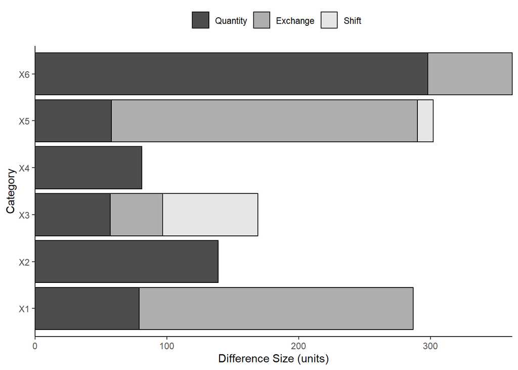

```r
categoryComponentsPlot (ctmatrix=Confusion2)
```

We can then calculate exchange and overall difference metrics

```r
exchangeDij(Confusion2)
```

```
##    X1 X2 X3 X4 X5 X6
## 1   0  0  0  0  0  0
## 2   0  0  0  0  0  0
## 3   0  0  0  0  0  0
## 4   0  0  0  0  0  0
## 5 208  0  0  0  0  0
## 6   0  0 40  0 24  0
```

```r
exchangeDj(Confusion2)
```

```
##   1   2   3   4   5   6
## 208   0  40   0 232  64
```

```r
overallAllocD(Confusion2)
```

```
## [1] 314
```

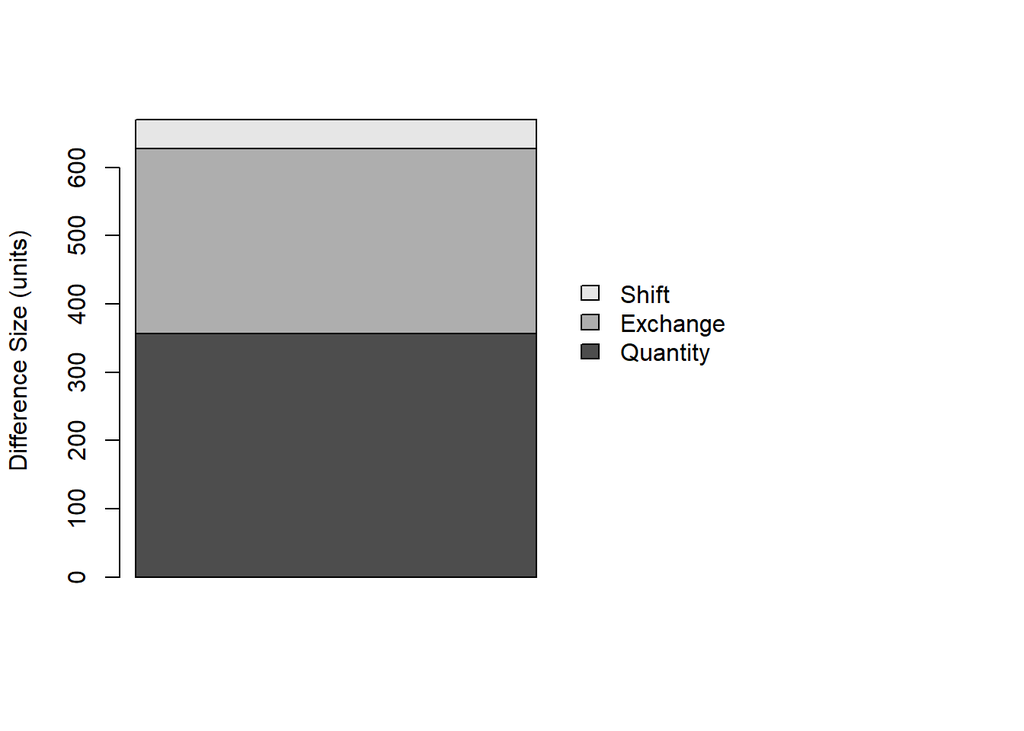

```r
overallComponentsPlot(ctmatrix=Confusion2)
```

```r
overallDiff(Confusion2)
```

```
## [1] 670
```

```r
overallDiffCatj(Confusion2)
```

```
##   1   2   3   4   5   6
## 287 139 169  81 302 362
```

```r
overallExchangeD(Confusion2)
```

```
## [1] 272
```

```r
overallQtyD(Confusion2)
```

```
## [1] 356
```

```r
overallShiftD(Confusion2)
```

```
## [1] 42
```

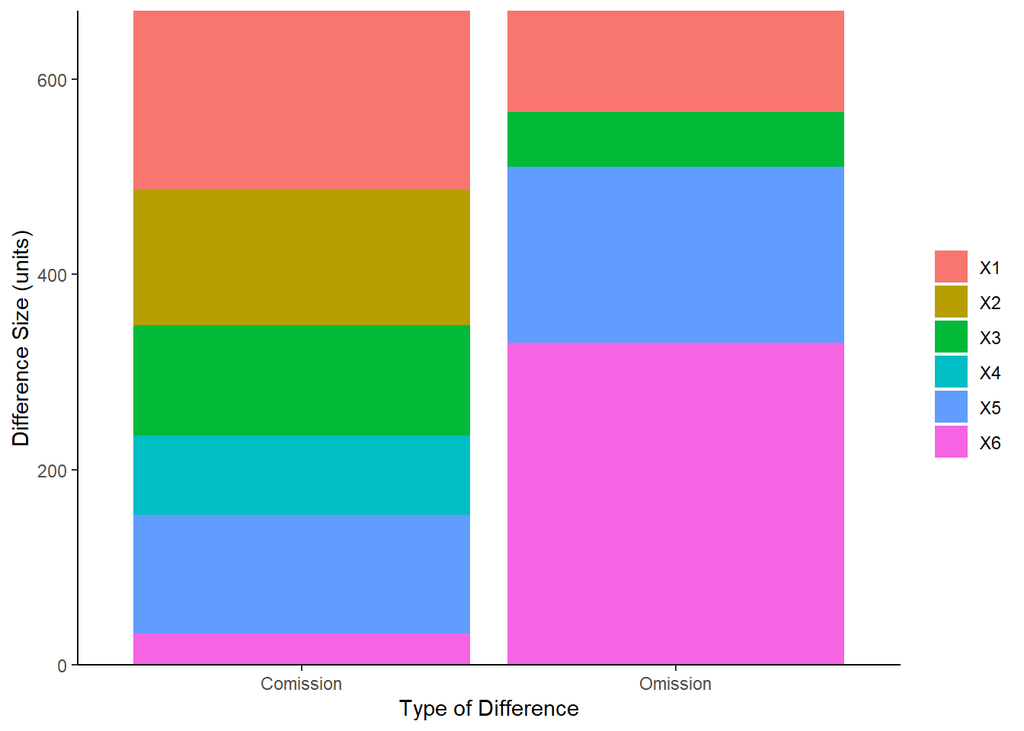

```r
overallSourcesPlot(ctmatrix=Confusion2)
```

```r
quantityDj(Confusion2)
```

```
##   1   2   3   4   5   6
##  79 139  57  81  58 298
```

We can then calculate shift difference at the category level from a contingency table derived from the crosstabulation between comparison variable and reference variable. Shift refers to the difference remaining after subtracting quantity difference and exchange from the overall difference

```r
shiftDj(Confusion2)
```

```
##  1  2  3  4  5  6
##  0  0 72  0 12  0
```

And then produce a stacked bar plot showing the ommission and commission components for each category

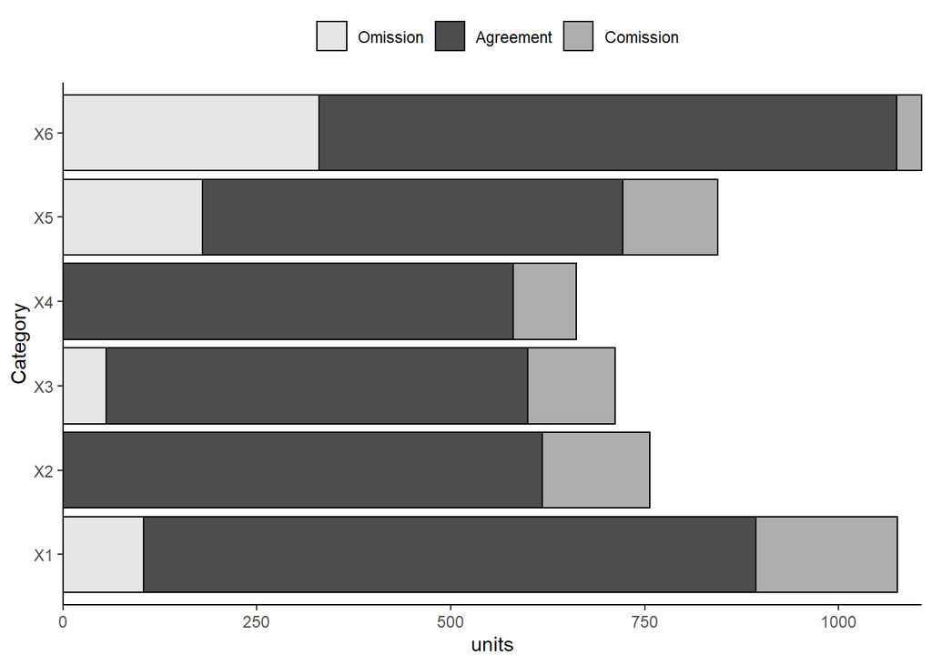

```r
categorySourcesPlot(ctmatrix=Confusion2)
```